# Cleaning Data in Python

*Datasets provided by DataCamp.com*

```python
import pandas as pd
import matplotlib.pyplot as plt
import numpy as np
```

## Cleaning outliers

*Data: subset of the Department of Buildings Job Application Filings dataset from the NYC Open Data portal. This dataset consists of job applications filed on January 22, 2017.*

```python
df = pd.read_csv('dob_job_application_filings_subset.csv',low_memory=False)
```

```python
df.head()
```

|  | Job # | Doc # | Borough | House # | Street Name | Block | Lot | Bin # | Job Type | Job Status | ... | Owner's Last Name | Owner's Business Name | Owner's House Number | Owner'sHouse Street Name | City | State | Zip | Owner'sPhone # | Job Description | DOBRunDate |
| --- | --- | --- | --- | --- | --- | --- | --- | --- | --- | --- | --- | --- | --- | --- | --- | --- | --- | --- | --- | --- | --- |
| 0 | 121577873 | 2 | MANHATTAN | 386 | PARK AVENUE SOUTH | 857 | 38 | 1016890 | A2 | D | ... | MIGLIORE | MACKLOWE MANAGEMENT | 126 | EAST 56TH STREET | NEW YORK | NY | 10222 | 2125545837 | GENERAL MECHANICAL & PLUMBING MODIFICATIONS AS... | 04/26/2013 12:00:00 AM |
| 1 | 520129502 | 1 | STATEN ISLAND | 107 | KNOX PLACE | 342 | 1 | 5161350 | A3 | A | ... | BLUMENBERG | NA | 107 | KNOX PLACE | STATEN ISLAND | NY | 10314 | 3477398892 | BUILDERS PAVEMENT PLAN 143 LF. ... | 04/26/2013 12:00:00 AM |
| 2 | 121601560 | 1 | MANHATTAN | 63 | WEST 131 STREET | 1729 | 9 | 1053831 | A2 | Q | ... | MARKOWITZ | 635 RIVERSIDE DRIVE NY LLC | 619 | WEST 54TH STREET | NEW YORK | NY | 10016 | 2127652555 | GENERAL CONSTRUCTION TO INCLUDE NEW PARTITIONS... | 04/26/2013 12:00:00 AM |
| 3 | 121601203 | 1 | MANHATTAN | 48 | WEST 25TH STREET | 826 | 69 | 1015610 | A2 | D | ... | CASALE | 48 W 25 ST LLC C/O BERNSTEIN | 150 | WEST 30TH STREET | NEW YORK | NY | 10001 | 2125941414 | STRUCTURAL CHANGES ON THE 5TH FLOOR (MOONDOG E... | 04/26/2013 12:00:00 AM |
| 4 | 121601338 | 1 | MANHATTAN | 45 | WEST 29 STREET | 831 | 7 | 1015754 | A3 | D | ... | LEE | HYUNG-HYANG REALTY CORP | 614 | 8 AVENUE | NEW YORK | NY | 10001 | 2019881222 | FILING HEREWITH FACADE REPAIR PLANS. WORK SCOP... | 04/26/2013 12:00:00 AM |

5 rows × 82 columns

```python
df.columns
```

```
Index(['Job #', 'Doc #', 'Borough', 'House #', 'Street Name', 'Block', 'Lot',
       'Bin #', 'Job Type', 'Job Status', 'Job Status Descrp',
       'Latest Action Date', 'Building Type', 'Community - Board', 'Cluster',
       'Landmarked', 'Adult Estab', 'Loft Board', 'City Owned', 'Little e',
       'PC Filed', 'eFiling Filed', 'Plumbing', 'Mechanical', 'Boiler',
       'Fuel Burning', 'Fuel Storage', 'Standpipe', 'Sprinkler', 'Fire Alarm',
       'Equipment', 'Fire Suppression', 'Curb Cut', 'Other',
       'Other Description', 'Applicant's First Name', 'Applicant's Last Name',
       'Applicant Professional Title', 'Applicant License #',
       'Professional Cert', 'Pre- Filing Date', 'Paid', 'Fully Paid',
       'Assigned', 'Approved', 'Fully Permitted', 'Initial Cost',
       'Total Est. Fee', 'Fee Status', 'Existing Zoning Sqft',
       'Proposed Zoning Sqft', 'Horizontal Enlrgmt', 'Vertical Enlrgmt',
       'Enlargement SQ Footage', 'Street Frontage', 'ExistingNo. of Stories',
       'Proposed No. of Stories', 'Existing Height', 'Proposed Height',
       'Existing Dwelling Units', 'Proposed Dwelling Units',
       'Existing Occupancy', 'Proposed Occupancy', 'Site Fill', 'Zoning Dist1',
       'Zoning Dist2', 'Zoning Dist3', 'Special District 1',
       'Special District 2', 'Owner Type', 'Non-Profit', 'Owner's First Name',
       'Owner's Last Name', 'Owner's Business Name', 'Owner's House Number',
       'Owner'sHouse Street Name', 'City ', 'State', 'Zip', 'Owner'sPhone #',
       'Job Description', 'DOBRunDate'],
      dtype='object')
```

**Delete dollar sign from columns**

```python
df['initial_cost'] = df['Initial Cost'].apply(lambda x: float(x[1:]))
df['total_est_fee'] = df['Total Est. Fee'].apply(lambda x: float(x[1:]))
```

**Dealing with outliers**

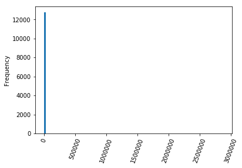

```python
df['Existing Zoning Sqft'].plot(kind='hist', bins=100, rot=70, logx=False, logy=False)
plt.show()
```

```python
p = np.percentile(df['Existing Zoning Sqft'].values,99)
```

```python
df2 = df[df['Existing Zoning Sqft'] < p]
```

```python
df2['Existing Zoning Sqft'].describe()
```

```
count    12717.000000
mean       131.608398
std        729.333544
min          0.000000
25%          0.000000
50%          0.000000
75%          0.000000
max       9890.000000
Name: Existing Zoning Sqft, dtype: float64
```

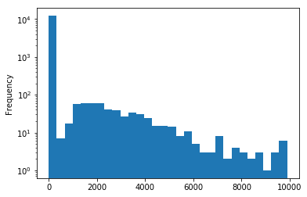

```python
df2['Existing Zoning Sqft'].plot(kind='hist', bins=30, logx=False, logy=True)
plt.show()
```

```python
df.info()
```

```
<class 'pandas.core.frame.DataFrame'>
RangeIndex: 12846 entries, 0 to 12845
Data columns (total 84 columns):
Job #                           12846 non-null int64
Doc #                           12846 non-null int64
Borough                         12846 non-null object
House #                         12846 non-null object
Street Name                     12846 non-null object
Block                           12846 non-null int64
Lot                             12846 non-null int64
Bin #                           12846 non-null int64
Job Type                        12846 non-null object
Job Status                      12846 non-null object
Job Status Descrp               12846 non-null object
Latest Action Date              12846 non-null object
Building Type                   12846 non-null object
Community - Board               12846 non-null object
Cluster                         0 non-null float64
Landmarked                      2067 non-null object
Adult Estab                     1 non-null object
Loft Board                      65 non-null object
City Owned                      1419 non-null object
Little e                        365 non-null object
PC Filed                        0 non-null float64
eFiling Filed                   12846 non-null object
Plumbing                        12846 non-null object
Mechanical                      12846 non-null object
Boiler                          12846 non-null object
Fuel Burning                    12846 non-null object
Fuel Storage                    12846 non-null object
Standpipe                       12846 non-null object
Sprinkler                       12846 non-null object
Fire Alarm                      12846 non-null object
Equipment                       12846 non-null object
Fire Suppression                12846 non-null object
Curb Cut                        12846 non-null object
Other                           12846 non-null object
Other Description               12846 non-null object
Applicant's First Name          12846 non-null object
Applicant's Last Name           12846 non-null object
```

[output cut: 34 more lines]

```
Owner's First Name              12846 non-null object
Owner's Last Name               12846 non-null object
Owner's Business Name           12846 non-null object
Owner's House Number            12846 non-null object
Owner'sHouse Street Name        12846 non-null object
City                            12846 non-null object
State                           12846 non-null object
Zip                             12846 non-null int64
Owner'sPhone #                  12846 non-null int64
Job Description                 12699 non-null object
DOBRunDate                      12846 non-null object
initial_cost                    12846 non-null float64
total_est_fee                   12846 non-null float64
dtypes: float64(5), int64(15), object(64)
memory usage: 8.2+ MB
```

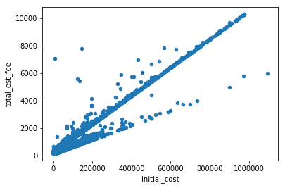

```python
df2 = df[(df.initial_cost > 0) & (df.initial_cost < np.percentile(df.initial_cost.values,99))]
df2 = df2[df2.total_est_fee < np.percentile(df2.total_est_fee.values,99)]

df2.plot(kind='scatter', x='initial_cost', y='total_est_fee')
plt.show()
```

## Melting and pivoting

**Melting**

*Data: measurements of air quality in different dates*

```python
airquality = pd.read_csv('airquality.csv')
```

```python
airquality.head()
```

|  | Ozone | Solar.R | Wind | Temp | Month | Day |
| --- | --- | --- | --- | --- | --- | --- |
| 0 | 41.0 | 190.0 | 7.4 | 67 | 5 | 1 |
| 1 | 36.0 | 118.0 | 8.0 | 72 | 5 | 2 |
| 2 | 12.0 | 149.0 | 12.6 | 74 | 5 | 3 |
| 3 | 18.0 | 313.0 | 11.5 | 62 | 5 | 4 |
| 4 | NaN | NaN | 14.3 | 56 | 5 | 5 |

```python
# melting : we turn columns into rows

# id_vars : columns that we do not want to melt
# value_vars : columns that we want to melt (if none, value_vars are the rest of the columns not specified by id_vars)
# var_name = name of the 'variable' column after melting
# value_name = name of the 'value' column after melting

print(airquality.head())

# Melt airquality: airquality_melt
airquality_melt = pd.melt(airquality, id_vars=['Month', 'Day'], var_name='measurement', value_name='reading')

print('\nAfter melting:\n')
# Print the head of airquality_melt
print(airquality_melt.head())
```

```
   Ozone  Solar.R  Wind  Temp  Month  Day
0   41.0    190.0   7.4    67      5    1
1   36.0    118.0   8.0    72      5    2
2   12.0    149.0  12.6    74      5    3
3   18.0    313.0  11.5    62      5    4
4    NaN      NaN  14.3    56      5    5

After melting:

   Month  Day measurement  reading
0      5    1       Ozone     41.0
1      5    2       Ozone     36.0
2      5    3       Ozone     12.0
3      5    4       Ozone     18.0
4      5    5       Ozone      NaN
```

**Pivoting**

```python
# Turn unique values into separate columns
```

```python
# Print the head of airquality_melt
print(airquality_melt.head())

# Pivot airquality_melt: airquality_pivot
airquality_pivot = pd.pivot_table(airquality_melt, index=['Month','Day'], columns='measurement', values='reading')
# By default: aggfunc=np.mean, so we can pivot also if there are duplicate values without specifying 'aggfunc'

print('\nAfter pivoting:\n')

# Print the head of airquality_pivot
print(airquality_pivot.head())

airquality_pivot = airquality_pivot.reset_index()
airquality_pivot.columns.name = None
print(airquality_pivot.head())
```

```
   Month  Day measurement  reading
0      5    1       Ozone     41.0
1      5    2       Ozone     36.0
2      5    3       Ozone     12.0
3      5    4       Ozone     18.0
4      5    5       Ozone      NaN

After pivoting:

measurement  Ozone  Solar.R  Temp  Wind
Month Day
5     1       41.0    190.0  67.0   7.4
      2       36.0    118.0  72.0   8.0
      3       12.0    149.0  74.0  12.6
      4       18.0    313.0  62.0  11.5
      5        NaN      NaN  56.0  14.3
   Month  Day  Ozone  Solar.R  Temp  Wind
0      5    1   41.0    190.0  67.0   7.4
1      5    2   36.0    118.0  72.0   8.0
2      5    3   12.0    149.0  74.0  12.6
3      5    4   18.0    313.0  62.0  11.5
4      5    5    NaN      NaN  56.0  14.3
```

**Other examples**

*Data: case counts of tuberculosis by country, year, gender, and age group*

```python
tb = pd.read_csv('tb.csv')
```

```python
tb.head()
```

|  | country | year | m014 | m1524 | m2534 | m3544 | m4554 | m5564 | m65 | mu | f014 | f1524 | f2534 | f3544 | f4554 | f5564 | f65 | fu |
| --- | --- | --- | --- | --- | --- | --- | --- | --- | --- | --- | --- | --- | --- | --- | --- | --- | --- | --- |
| 0 | AD | 2000 | 0.0 | 0.0 | 1.0 | 0.0 | 0.0 | 0.0 | 0.0 | NaN | NaN | NaN | NaN | NaN | NaN | NaN | NaN | NaN |
| 1 | AE | 2000 | 2.0 | 4.0 | 4.0 | 6.0 | 5.0 | 12.0 | 10.0 | NaN | 3.0 | 16.0 | 1.0 | 3.0 | 0.0 | 0.0 | 4.0 | NaN |
| 2 | AF | 2000 | 52.0 | 228.0 | 183.0 | 149.0 | 129.0 | 94.0 | 80.0 | NaN | 93.0 | 414.0 | 565.0 | 339.0 | 205.0 | 99.0 | 36.0 | NaN |
| 3 | AG | 2000 | 0.0 | 0.0 | 0.0 | 0.0 | 0.0 | 0.0 | 1.0 | NaN | 1.0 | 1.0 | 1.0 | 0.0 | 0.0 | 0.0 | 0.0 | NaN |
| 4 | AL | 2000 | 2.0 | 19.0 | 21.0 | 14.0 | 24.0 | 19.0 | 16.0 | NaN | 3.0 | 11.0 | 10.0 | 8.0 | 8.0 | 5.0 | 11.0 | NaN |

```python
# Melt tb: tb_melt
tb_melt = pd.melt(tb, id_vars=['country', 'year'])
print(tb_melt.head())

# Create the 'gender' column
tb_melt['gender'] = tb_melt.variable.str[0]

# Create the 'age_group' column
tb_melt['age_group'] = tb_melt.variable.str[1:]

# Print the head of tb_melt
print(tb_melt.head())
```

```
  country  year variable  value
0      AD  2000     m014    0.0
1      AE  2000     m014    2.0
2      AF  2000     m014   52.0
3      AG  2000     m014    0.0
4      AL  2000     m014    2.0
  country  year variable  value gender age_group
0      AD  2000     m014    0.0      m       014
1      AE  2000     m014    2.0      m       014
2      AF  2000     m014   52.0      m       014
3      AG  2000     m014    0.0      m       014
4      AL  2000     m014    2.0      m       014
```

*Data: dataset consisting of Ebola cases and death counts by state and country.*

```python
ebola = pd.read_csv('ebola.csv')
```

```python
ebola.head()
```

|  | Date | Day | Cases_Guinea | Cases_Liberia | Cases_SierraLeone | Cases_Nigeria | Cases_Senegal | Cases_UnitedStates | Cases_Spain | Cases_Mali | Deaths_Guinea | Deaths_Liberia | Deaths_SierraLeone | Deaths_Nigeria | Deaths_Senegal | Deaths_UnitedStates | Deaths_Spain | Deaths_Mali |
| --- | --- | --- | --- | --- | --- | --- | --- | --- | --- | --- | --- | --- | --- | --- | --- | --- | --- | --- |
| 0 | 1/5/2015 | 289 | 2776.0 | NaN | 10030.0 | NaN | NaN | NaN | NaN | NaN | 1786.0 | NaN | 2977.0 | NaN | NaN | NaN | NaN | NaN |
| 1 | 1/4/2015 | 288 | 2775.0 | NaN | 9780.0 | NaN | NaN | NaN | NaN | NaN | 1781.0 | NaN | 2943.0 | NaN | NaN | NaN | NaN | NaN |
| 2 | 1/3/2015 | 287 | 2769.0 | 8166.0 | 9722.0 | NaN | NaN | NaN | NaN | NaN | 1767.0 | 3496.0 | 2915.0 | NaN | NaN | NaN | NaN | NaN |
| 3 | 1/2/2015 | 286 | NaN | 8157.0 | NaN | NaN | NaN | NaN | NaN | NaN | NaN | 3496.0 | NaN | NaN | NaN | NaN | NaN | NaN |
| 4 | 12/31/2014 | 284 | 2730.0 | 8115.0 | 9633.0 | NaN | NaN | NaN | NaN | NaN | 1739.0 | 3471.0 | 2827.0 | NaN | NaN | NaN | NaN | NaN |

```python
# Melt ebola: ebola_melt
ebola_melt = pd.melt(ebola, id_vars=['Date', 'Day'], var_name='type_country', value_name='counts')

# Create the 'str_split' column
ebola_melt['str_split'] = ebola_melt.type_country.str.split('_')

# Create the 'type' column
ebola_melt['type'] = ebola_melt.str_split.str.get(0)

# Create the 'country' column
ebola_melt['country'] = ebola_melt.str_split.str.get(1)

ebola_melt.drop(['type_country', 'str_split'],axis=1,inplace=True)

# Print the head of ebola_melt
print('\n\n',ebola_melt.head())
```

```
          Date  Day  counts   type country
0    1/5/2015  289  2776.0  Cases  Guinea
1    1/4/2015  288  2775.0  Cases  Guinea
2    1/3/2015  287  2769.0  Cases  Guinea
3    1/2/2015  286     NaN  Cases  Guinea
4  12/31/2014  284  2730.0  Cases  Guinea
```

## Combining Datasets

**Globbing & concatenate**

```
import glob

csv_files = glob.glob('*.csv')

frames = []
for csv in csv_files:
    df = pd.read_csv(csv)
    frames.append(df)

uber = pd.concat(frames)
```

pd.concat concatenates per default vertically (adding rows) (axis=0)

If we want to concatenate horizontally, add axis=1

**Merging**

pd.merge function

```
pd.merge(left, right, how='inner', on=None, left_on=None, right_on=None,
         left_index=False, right_index=False, sort=True)
```

Dataframe.merge function

```
df.merge(right, how='inner', on=None, left_on=None, right_on=None,
         left_index=False, right_index=False, sort=False)
```

how: default ‘inner’

- left: use only keys from left frame, similar to a SQL left outer join; preserve key order
- right: use only keys from right frame, similar to a SQL right outer join; preserve key order
- outer: use union of keys from both frames, similar to a SQL full outer join; sort keys lexicographically
- inner: use intersection of keys from both frames, similar to a SQL inner join; preserve the order of the left keys

## Datatypes

*Data: information about how much a customer tipped, whether the customer was male or female, a smoker or not, etc.*

```python
tips = pd.read_csv('tips.csv')
```

```python
tips.head()
```

|  | total_bill | tip | sex | smoker | day | time | size |
| --- | --- | --- | --- | --- | --- | --- | --- |
| 0 | 16.99 | 1.01 | Female | No | Sun | Dinner | 2 |
| 1 | 10.34 | 1.66 | Male | No | Sun | Dinner | 3 |
| 2 | 21.01 | 3.50 | Male | No | Sun | Dinner | 3 |
| 3 | 23.68 | 3.31 | Male | No | Sun | Dinner | 2 |
| 4 | 24.59 | 3.61 | Female | No | Sun | Dinner | 4 |

```python
tips.dtypes
```

```
total_bill    float64
tip           float64
sex            object
smoker         object
day            object
time           object
size            int64
dtype: object
```

```python
tips.sex = tips.sex.astype('category') # encoding a column as cateogory also saves memory!
tips.smoker = tips.smoker.astype('category')

tips['total_bill'] = pd.to_numeric(tips['total_bill'], errors='coerce')
tips['tip'] = pd.to_numeric(tips['tip'], errors='coerce')
# Values that cannot be converted to numeric will become NaN values.

tips.info()
```

```
<class 'pandas.core.frame.DataFrame'>
RangeIndex: 244 entries, 0 to 243
Data columns (total 7 columns):
total_bill    244 non-null float64
tip           244 non-null float64
sex           244 non-null category
smoker        244 non-null category
day           244 non-null object
time          244 non-null object
size          244 non-null int64
dtypes: category(2), float64(2), int64(1), object(2)
memory usage: 10.3+ KB
```

## Regular Expressions

```python
import re # Import the regular expression module

# Compile the pattern: prog
prog = re.compile('\d{3}-\d{3}-\d{4}') # 3 digits - 3 digits - 4 digits
# See if the pattern matches
result = prog.match('123-456-7890')
print(bool(result))

pattern2 = bool(re.match(pattern='\$\d+\.\d{2}', string='$123.45'))
# + means one or more of the previous
# * means zero or more of the previous
# we need to escape the dollar sign and the point
# we can also add: ^ to indicate start of string and $ to indicate end of string
print(pattern2)

pattern3 = bool(re.match(pattern='[A-Z]\w*', string='Australia'))
print(pattern3)

# Find all matches
matches = re.findall('\d+', 'the recipe calls for 10 strawberries and 1 banana')
print(matches)
```

```
True
True
True
['10', '1']
```

```
# Remove dollar sign from a column with prices using regular expressions:
tips['total_dollar_re'] = tips.total_dollar.apply(lambda x: re.findall('\d+\.\d+', x)[0])

# Another method:
tips['total_dollar_replace'] = tips.total_dollar.apply(lambda x: x.replace('$', ''))
```

## Duplicates and missing values

For duplicates, we can use panda's df.drop_duplicates()

For missing values, we can drop them or fill them:

- df.dropna()
- series.fillna(np.mean(series))

## Asserts

```python
ebola2 = ebola.fillna(0)
# Assert that there are no missing values
assert ebola2.notnull().all().all()

# Assert that all values are >= 0
assert (ebola2>=0).all().all()
```

## Case study

*Data: Gapminder dataset, life expectancy level data by country and year*

```python
gap = pd.read_csv('gapminder.csv',index_col = 0)
```

```python
gap.sort_index().head(12)
```

|  | 1800 | 1801 | 1802 | 1803 | 1804 | 1805 | 1806 | 1807 | 1808 | 1809 | ... | 2008 | 2009 | 2010 | 2011 | 2012 | 2013 | 2014 | 2015 | 2016 | Life expectancy |
| --- | --- | --- | --- | --- | --- | --- | --- | --- | --- | --- | --- | --- | --- | --- | --- | --- | --- | --- | --- | --- | --- |
| 0 | NaN | NaN | NaN | NaN | NaN | NaN | NaN | NaN | NaN | NaN | ... | NaN | NaN | NaN | NaN | NaN | NaN | NaN | NaN | NaN | Abkhazia |
| 0 | NaN | NaN | NaN | NaN | NaN | NaN | NaN | NaN | NaN | NaN | ... | NaN | NaN | NaN | NaN | NaN | NaN | NaN | NaN | NaN | Abkhazia |
| 0 | NaN | NaN | NaN | NaN | NaN | NaN | NaN | NaN | NaN | NaN | ... | NaN | NaN | NaN | NaN | NaN | NaN | NaN | NaN | NaN | Abkhazia |
| 1 | 28.21 | 28.2 | 28.19 | 28.18 | 28.17 | 28.16 | 28.15 | 28.14 | 28.13 | 28.12 | ... | NaN | NaN | NaN | NaN | NaN | NaN | NaN | NaN | NaN | Afghanistan |
| 1 | NaN | NaN | NaN | NaN | NaN | NaN | NaN | NaN | NaN | NaN | ... | NaN | NaN | NaN | NaN | NaN | NaN | NaN | NaN | NaN | Afghanistan |
| 1 | NaN | NaN | NaN | NaN | NaN | NaN | NaN | NaN | NaN | NaN | ... | 52.8 | 53.3 | 53.6 | 54.0 | 54.4 | 54.8 | 54.9 | 53.8 | 52.72 | Afghanistan |
| 2 | NaN | NaN | NaN | NaN | NaN | NaN | NaN | NaN | NaN | NaN | ... | NaN | NaN | NaN | NaN | NaN | NaN | NaN | NaN | NaN | Akrotiri and Dhekelia |
| 2 | NaN | NaN | NaN | NaN | NaN | NaN | NaN | NaN | NaN | NaN | ... | NaN | NaN | NaN | NaN | NaN | NaN | NaN | NaN | NaN | Akrotiri and Dhekelia |
| 2 | NaN | NaN | NaN | NaN | NaN | NaN | NaN | NaN | NaN | NaN | ... | NaN | NaN | NaN | NaN | NaN | NaN | NaN | NaN | NaN | Akrotiri and Dhekelia |
| 3 | 35.40 | 35.4 | 35.40 | 35.40 | 35.40 | 35.40 | 35.40 | 35.40 | 35.40 | 35.40 | ... | NaN | NaN | NaN | NaN | NaN | NaN | NaN | NaN | NaN | Albania |
| 3 | NaN | NaN | NaN | NaN | NaN | NaN | NaN | NaN | NaN | NaN | ... | NaN | NaN | NaN | NaN | NaN | NaN | NaN | NaN | NaN | Albania |
| 3 | NaN | NaN | NaN | NaN | NaN | NaN | NaN | NaN | NaN | NaN | ... | 76.8 | 77.0 | 77.2 | 77.4 | 77.5 | 77.7 | 77.9 | 78.0 | 78.10 | Albania |

12 rows × 218 columns

```python
def check_null_or_valid(row_data):
    """Function that takes a row of data, drops all missing values,
    and checks if all remaining values are greater than or equal to 0
    """
    no_na = row_data.dropna()
    numeric = pd.to_numeric(no_na)
    ge0 = numeric >= 0
    return ge0

# Check whether the last column is 'Life expectancy'
assert gap.columns[-1] == 'Life expectancy'

# Check whether the values in the row are valid
assert gap.iloc[:, :-1].apply(check_null_or_valid, axis=1).all().all()

# Check that there is not only one instance of each country
# assert gap['Life expectancy'].value_counts()[0] == 1
```

```python
# Melt gapminder: gapminder_melt
gap = pd.melt(gap,id_vars = 'Life expectancy')
gap.columns = ['country','year','life_expectancy']
```

```python
gap.head()
```

|  | country | year | life_expectancy |
| --- | --- | --- | --- |
| 0 | Abkhazia | 1800 | NaN |
| 1 | Afghanistan | 1800 | 28.21 |
| 2 | Akrotiri and Dhekelia | 1800 | NaN |
| 3 | Albania | 1800 | 35.40 |
| 4 | Algeria | 1800 | 28.82 |

```python
# Convert the year column to numeric
gap.year = pd.to_numeric(gap.year)

assert gap.country.dtypes == np.object
assert gap.year.dtypes == np.int64
assert gap.life_expectancy.dtypes == np.float64
```

```python
# Check misspellings in country names

countries = gap.country

# Drop all the duplicates from countries
countries = countries.drop_duplicates()
pattern = '^[A-Za-z\.\s]*$'
mask = countries.str.contains(pattern)
mask_inverse = ~mask
invalid_countries = countries[mask_inverse]
print(invalid_countries)
```

```
49            Congo, Dem. Rep.
50                 Congo, Rep.
53               Cote d'Ivoire
73      Falkland Is (Malvinas)
93               Guinea-Bissau
98            Hong Kong, China
118    United Korea (former)\n
131               Macao, China
132             Macedonia, FYR
145      Micronesia, Fed. Sts.
161            Ngorno-Karabakh
187             St. Barthélemy
193     St.-Pierre-et-Miquelon
225                Timor-Leste
251      Virgin Islands (U.S.)
252       North Yemen (former)
253       South Yemen (former)
258                      Åland
Name: country, dtype: object
```

```python
# Check missing values

assert pd.notnull(gap.country).all()
assert  pd.notnull(gap.year).all()

gap = gap.dropna()
print(gap.shape)
```

```
(43857, 3)
```

**Plots**

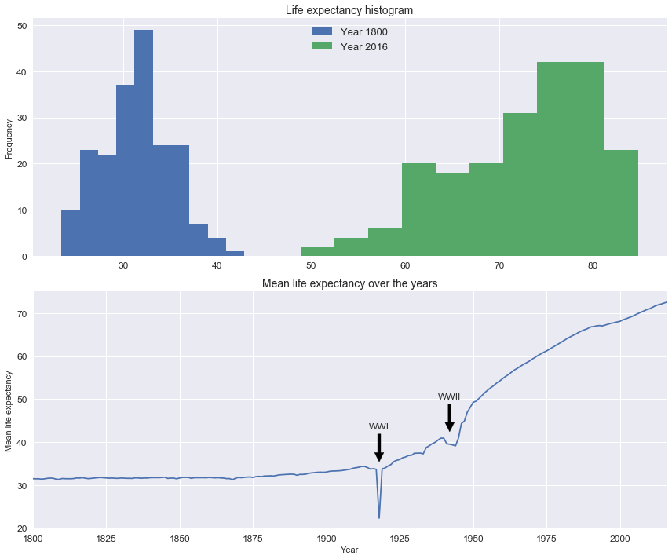

```python
plt.style.use('seaborn')
plt.subplots(figsize=(12,10))
# Add first subplot
plt.subplot(2, 1, 1)

# Histogram of life_expectancy
gap1800 = gap[gap.year==1800]
gap1800.life_expectancy.plot(kind='hist',fontsize=12,label='Year 1800')
plt.title('Life expectancy histogram in 1800',fontsize=16)

gap2016 = gap[gap.year==2016]
gap2016.life_expectancy.plot(kind='hist',fontsize=12,label='Year 2016')
plt.title('Life expectancy histogram',fontsize=14)
plt.legend(loc='upper center',fontsize=13)


# Group gapminder: gapminder_agg
gapminder_agg = gap.groupby('year')['life_expectancy'].mean()

plt.subplot(2, 1, 2)

# Create a line plot of life expectancy per year
gapminder_agg.plot(fontsize=12)

plt.annotate('WWI', xy=(1918, 35), xytext=(1918, 43), fontsize=12, horizontalalignment='center',
            arrowprops=dict(facecolor='black', shrink=0.05))

plt.annotate('WWII', xy=(1942, 42), xytext=(1942, 50), fontsize=12, horizontalalignment='center',
            arrowprops=dict(facecolor='black', shrink=0.05))


plt.title('Mean life expectancy over the years',fontsize=14)
plt.ylabel('Mean life expectancy')
plt.xlabel('Year')

plt.tight_layout()
plt.show()
```